# Resumen Tecnico

137760 Chacon Guillaumin Jorge Rodrigo , 137503 Diego Zayas Hernandez, 124251 Fabiola Farrera Fonseca

Monday, October 27, 2014

# Carga de los Datos

## Lectura de Datos

En esta seccion se realiza la lectura de los 99 archivos proporcionados por la Secretaria de Salud con respecto al numero de casos por intoxicacion por picadura de alacran, la carga se realiza en el siguiente orden:casos registrados por fuente notificacion, casos registrados por grupo de edad y casos registrados por mes. Para cada una de las tres categorias antes mencionadas se realiza en un inicio la carga de los datos correspondientes al genero femenino, posteriormente el masculino y finalmente los datos generales. Se realiza a su vez la consolidacion de los archivos por categoria, para generan tres archivos consolidados “Picadura.Alacran.Fuente”,“Picadura.Alacran.Edad” y “Picadura.Alacran.Periodo”.

```r
#Fuente de Notificacion
library(plyr)

alacran.fuente <- NULL
titulos.fuente <- NULL
for (i in 1:11){
alacran.fuente[[i]] <- read.csv(paste("./DATOS/BRUTOS/fuente-f",i+2002,".csv",sep=""),stringsAsFactors=FALSE)
titulos.fuente[i] <- paste("fuente-f",i+2002,sep="")
}
for (i in 12:22){
alacran.fuente[[i]] <- read.csv(paste("./DATOS/BRUTOS/fuente-m",i+1991,".csv",sep=""),stringsAsFactors=FALSE)
titulos.fuente[i] <- paste("fuente-m",i+1991,sep="")
}
for (i in 23:33){
alacran.fuente[[i]] <- read.csv(paste("./DATOS/BRUTOS/fuente-g",i+1980,".csv",sep=""),stringsAsFactors=FALSE)
titulos.fuente[i] <- paste("fuente-g",i+1980,sep="")
}

names(alacran.fuente) <- titulos.fuente

picadura.alacran.fuente <- ldply(alacran.fuente,data.frame)

save(picadura.alacran.fuente, file="./DATOS/BRUTOS/Picadura_Alacran_Fuente.RData")

#Grupo de Edad

alacran.edad <- NULL
titulos.edad <- NULL
for (i in 1:11){
alacran.edad[[i]] <- read.csv(paste("./DATOS/BRUTOS/edad-f",i+2002,".csv",sep=""),stringsAsFactors=FALSE)
titulos.edad[i] <- paste("edad-f",i+2002,sep="")
}
for (i in 12:22){
alacran.edad[[i]] <- read.csv(paste("./DATOS/BRUTOS/edad-m",i+1991,".csv",sep=""),stringsAsFactors=FALSE)
titulos.edad[i] <- paste("edad-m",i+1991,sep="")
}
for (i in 23:33){
alacran.edad[[i]] <- read.csv(paste("./DATOS/BRUTOS/edad-g",i+1980,".csv",sep=""),stringsAsFactors=FALSE)
titulos.edad[i] <- paste("edad-g",i+1980,sep="")
}

names(alacran.edad) <- titulos.edad

picadura.alacran.edad <- ldply(alacran.edad,data.frame)

save(picadura.alacran.edad, file="./DATOS/BRUTOS/Picadura_Alacran_Edad.RData")

#Mes de Observacion

alacran.mes <- NULL
titulos.mes <- NULL
for (i in 1:11){
alacran.mes[[i]] <- read.csv(paste("./DATOS/BRUTOS/mes-f",i+2002,".csv",sep=""),stringsAsFactors=FALSE)
titulos.mes[i] <- paste("mes-f",i+2002,sep="")
}
for (i in 12:22){
alacran.mes[[i]] <- read.csv(paste("./DATOS/BRUTOS/mes-m",i+1991,".csv",sep=""),stringsAsFactors=FALSE)
titulos.mes[i] <- paste("mes-m",i+1991,sep="")
}
for (i in 23:33){
alacran.mes[[i]] <- read.csv(paste("./DATOS/BRUTOS/mes-g",i+1980,".csv",sep=""),stringsAsFactors=FALSE)
titulos.mes[i] <- paste("mes-g",i+1980,sep="")
}

names(alacran.mes) <- titulos.mes
picadura.alacran.mes <- ldply(alacran.mes,data.frame)

save(picadura.alacran.mes, file="./DATOS/BRUTOS/Picadura_Alacran_Mes.RData")
```

## Inspeccion de los Datos

A continuacion, con el proposito de introducir el contenido y de los archivos consolidados se realiza una extraccion de cada uno de ello, se toman de cada uno las primeras 6 observaciones.

```r
head(picadura.alacran.fuente)
```

```
           .id               Estado SALUD IMSS.ORD ISSSTE IMSS.OP DIF
1 fuente-f2003      Aguascalientes    654       20      1       0   0
2 fuente-f2003     Baja California      9       21      1       0   0
3 fuente-f2003 Baja California Sur     30        3      6       0   0
4 fuente-f2003            Campeche     20        1      2      11   0
5 fuente-f2003            Coahuila     17       27      0       4   0
6 fuente-f2003              Colima   3196     1341     55       0   0
  PEMEX SEDENA SEMAR OTRAS Total
1     0      0     0     0   675
2     0      0     0    11    42
3     0      0     0     0    39
4     0      0     0     0    34
5     0      0     0     1    49
6     0      4    48     0  4644
```

```r
head(picadura.alacran.edad)
```

```
         .id               Estado X.0.1. X.1.4. X.5.9. X.10.14. X.15.19.
1 edad-f2003      Aguascalientes       3     43     70       83       83
2 edad-f2003     Baja California       1      1      5        6        2
3 edad-f2003 Baja California Sur       1      7      2        1        5
4 edad-f2003            Campeche       0      3      6        3        5
5 edad-f2003            Coahuila       1      1      1        4       11
6 edad-f2003              Colima      18    266    376      495      613
  X.20.24. X.25.44. X.45.49. X.50.59. X.60.64. X.64.... Ign. Total
1       73      180       41       47       11       41    0   675
2        5       16        2        3        0        1    0    42
3        7        9        2        5        0        0    0    39
4        1        9        3        4        0        0    0    34
5        7       22        1        1        0        0    0    49
6      497     1437      228      351      128      224   11  4644
```

```r
head(picadura.alacran.mes)
```

```
        .id               Estado   Tasa. Total ENE FEB MAR ABR MAY JUN JUL
1 mes-f2003      Aguascalientes   130.21   675  39  40  49 115  80  72  49
2 mes-f2003     Baja California     3.06    42   1   2   2   1   4   1   3
3 mes-f2003 Baja California Sur    16.79    39   2   1   1   3   9   2   5
4 mes-f2003            Campeche     9.19    34   2   7   5   5   3   0   4
5 mes-f2003            Coahuila     3.98    49   0   1   2   4   3   5  12
6 mes-f2003              Colima  1612.74  4644 378 359 266 400 342 388 503
  AGO SEP OCT NOV DIC
1  52  62  57  32  28
2  15   6   2   4   1
3   5   3   2   5   1
4   1   2   1   0   4
5   2  12   4   1   3
6 414 415 498 363 318
```

Con el mismo fin, se presentan las dimensiones de cada uno de los archivos consolidados, las variables que contiene cada uno de los archivos y su clase.

Dimensiones:

```r
dim(picadura.alacran.fuente)
```

```
[1] 1056   12
```

```r
dim(picadura.alacran.edad)
```

```
[1] 1056   15
```

```r
dim(picadura.alacran.mes)
```

```
[1] 1056   16
```

Variables y sus Clases:

```r
str(picadura.alacran.fuente)
```

```
'data.frame':   1056 obs. of  12 variables:
 $ .id     : chr  "fuente-f2003" "fuente-f2003" "fuente-f2003" "fuente-f2003" ...
 $ Estado  : chr  "Aguascalientes " "Baja California " "Baja California Sur " "Campeche " ...
 $ SALUD   : chr  "654" "9" "30" "20" ...
 $ IMSS.ORD: chr  "20" "21" "3" "1" ...
 $ ISSSTE  : chr  "1" "1" "6" "2" ...
 $ IMSS.OP : chr  "0" "0" "0" "11" ...
 $ DIF     : chr  "0" "0" "0" "0" ...
 $ PEMEX   : chr  "0" "0" "0" "0" ...
 $ SEDENA  : chr  "0" "0" "0" "0" ...
 $ SEMAR   : chr  "0" "0" "0" "0" ...
 $ OTRAS   : chr  "0" "11" "0" "0" ...
 $ Total   : chr  "675" "42" "39" "34" ...
```

```r
str(picadura.alacran.edad)
```

```
'data.frame':   1056 obs. of  15 variables:
 $ .id     : chr  "edad-f2003" "edad-f2003" "edad-f2003" "edad-f2003" ...
 $ Estado  : chr  "Aguascalientes " "Baja California " "Baja California Sur " "Campeche " ...
 $ X.0.1.  : int  3 1 1 0 1 18 1 5 1 23 ...
 $ X.1.4.  : chr  "43" "1" "7" "3" ...
 $ X.5.9.  : chr  "70" "5" "2" "6" ...
 $ X.10.14.: chr  "83" "6" "1" "3" ...
 $ X.15.19.: chr  "83" "2" "5" "5" ...
 $ X.20.24.: chr  "73" "5" "7" "1" ...
 $ X.25.44.: chr  "180" "16" "9" "9" ...
 $ X.45.49.: chr  "41" "2" "2" "3" ...
 $ X.50.59.: chr  "47" "3" "5" "4" ...
 $ X.60.64.: chr  "11" "0" "0" "0" ...
 $ X.64....: chr  "41" "1" "0" "0" ...
 $ Ign.    : int  0 0 0 0 0 11 0 0 0 3 ...
 $ Total   : chr  "675" "42" "39" "34" ...
```

```r
str(picadura.alacran.mes)
```

```
'data.frame':   1056 obs. of  16 variables:
 $ .id   : chr  "mes-f2003" "mes-f2003" "mes-f2003" "mes-f2003" ...
 $ Estado: chr  "Aguascalientes " "Baja California " "Baja California Sur " "Campeche " ...
 $ Tasa. : chr  "130.21" "3.06" "16.79" "9.19" ...
 $ Total : chr  "675" "42" "39" "34" ...
 $ ENE   : chr  "39" "1" "2" "2" ...
 $ FEB   : chr  "40" "2" "1" "7" ...
 $ MAR   : chr  "49" "2" "1" "5" ...
 $ ABR   : chr  "115" "1" "3" "5" ...
 $ MAY   : chr  "80" "4" "9" "3" ...
 $ JUN   : chr  "72" "1" "2" "0" ...
 $ JUL   : chr  "49" "3" "5" "4" ...
 $ AGO   : chr  "52" "15" "5" "1" ...
 $ SEP   : chr  "62" "6" "3" "2" ...
 $ OCT   : chr  "57" "2" "2" "1" ...
 $ NOV   : chr  "32" "4" "5" "0" ...
 $ DIC   : chr  "28" "1" "1" "4" ...
```

# Organizacion de los Datos

Con el mismo objetivo con que se realiza la limpieza de los datos, se lleva a cabo la organizacion de los datos; los cambios se realizados se presentan a continuacion.

## Inclusion de las variables Periodo y Sexo

Considerando necesaria la segregacion de los datos por periodo en que se suscita la picadura de alacran y por sexo se introducen dos nuevas variables, periodo y genero, en cada uno de los archivos.

```r
picadura.alacran.fuente$Periodo <- factor(substr(picadura.alacran.fuente$.id,9,12), ordered=TRUE)
picadura.alacran.fuente$Sexo <- factor(substr(picadura.alacran.fuente$.id,8,8))
picadura.alacran.fuente$.id <- NULL
picadura.alacran.fuente <- within(picadura.alacran.fuente,{
  Sexo <- gsub("m","Masculino",Sexo,fixed=TRUE)
  Sexo <- gsub("f","Femenino",Sexo,fixed=TRUE)
  Sexo <- gsub("g","General",Sexo,fixed=TRUE)
 })

save(picadura.alacran.fuente, file="./DATOS/PROCESADOS/Picadura_Alacran_Fuente(Sexo-Periodo).RData")

picadura.alacran.edad$Periodo <- factor(substr(picadura.alacran.edad$.id,7,10), ordered=TRUE)
picadura.alacran.edad$Sexo <- factor(substr(picadura.alacran.edad$.id,6,6))
picadura.alacran.edad$.id <- NULL
picadura.alacran.edad <- within(picadura.alacran.edad,{
  Sexo <- gsub("m","Masculino",Sexo,fixed=TRUE)
  Sexo <- gsub("f","Femenino",Sexo,fixed=TRUE)
  Sexo <- gsub("g","General",Sexo,fixed=TRUE)
 })

save(picadura.alacran.edad, file="./DATOS/PROCESADOS/Picadura_Alacran_Edad(Sexo-Periodo).RData")

picadura.alacran.mes$Periodo <- factor(substr(picadura.alacran.mes$.id,6,9), ordered=TRUE)
picadura.alacran.mes$Sexo <- factor(substr(picadura.alacran.mes$.id,5,5))
picadura.alacran.mes$.id <- NULL
picadura.alacran.mes <- within(picadura.alacran.mes,{
  Sexo <- gsub("m","Masculino",Sexo,fixed=TRUE)
  Sexo <- gsub("f","Femenino",Sexo,fixed=TRUE)
  Sexo <- gsub("g","General",Sexo,fixed=TRUE)
 })

save(picadura.alacran.mes, file="./DATOS/PROCESADOS/Picadura_Alacran_Mes(Sexo-Periodo).RData")
```

# Limpieza de los Datos

Con el fin de obtener datos de mayor calidad y fiabilidad, se realiza la limpieza de los tres archivos consolidados, las modificaciones necesarias se presentan a continuacion.

La primera modificacion considerada necesaria es eliminar los espacios que se se encuentran en los datos numericos del archivo “Picadura.Alacran.Fuente”, “Picadura.Alacran.Edad” y “Picadura.Alacran.Mes”

```r
picadura.alacran.mes <- within(picadura.alacran.mes, {
     ENE <- gsub("[ ]{1,}","",ENE)
     FEB <- gsub("[ ]{1,}","",FEB)
     MAR <- gsub("[ ]{1,}","",MAR)
     ABR <- gsub("[ ]{1,}","",ABR)
     MAY <- gsub("[ ]{1,}","",MAY)
     JUN <- gsub("[ ]{1,}","",JUN)
     JUL <- gsub("[ ]{1,}","",JUL)
     AGO <- gsub("[ ]{1,}","",AGO)
     SEP <- gsub("[ ]{1,}","",SEP)
     OCT <- gsub("[ ]{1,}","",OCT)
     NOV <- gsub("[ ]{1,}","",NOV)
     DIC <- gsub("[ ]{1,}","",DIC)
     Total <- gsub("[ ]{1,}","",Total)
     Tasa. <- gsub("[ ]{1,}","",Tasa.)
 })

picadura.alacran.fuente <- within(picadura.alacran.fuente, {
     SALUD <- gsub("[ ]{1,}","",SALUD)
     IMSS.ORD <- gsub("[ ]{1,}","",IMSS.ORD)
     ISSSTE <- gsub("[ ]{1,}","",ISSSTE)
     IMSS.OP <- gsub("[ ]{1,}","",IMSS.OP)
     DIF <- gsub("[ ]{1,}","",DIF)
     PEMEX <- gsub("[ ]{1,}","",PEMEX)
     SEDENA <- gsub("[ ]{1,}","",SEDENA)
     SEMAR <- gsub("[ ]{1,}","",SEMAR)
     OTRAS <- gsub("[ ]{1,}","",OTRAS)
     Total <- gsub("[ ]{1,}","",Total)
 })

picadura.alacran.edad <- within(picadura.alacran.edad,{
  X.0.1. <- gsub("[ ]{1,}","",X.0.1.)
  X.1.4. <- gsub("[ ]{1,}","",X.1.4.)
  X.5.9. <- gsub("[ ]{1,}","",X.5.9.)
  X.10.14. <- gsub("[ ]{1,}","",X.10.14.)
  X.15.19. <- gsub("[ ]{1,}","",X.15.19.)
  X.20.24. <- gsub("[ ]{1,}","",X.20.24.)
  X.25.44. <- gsub("[ ]{1,}","",X.25.44.)
  X.45.49. <- gsub("[ ]{1,}","",X.45.49.)
  X.50.59. <- gsub("[ ]{1,}","",X.50.59.)
  X.60.64. <- gsub("[ ]{1,}","",X.60.64.)
  X.64.... <- gsub("[ ]{1,}","",X.64....)
  Ign. <- gsub("[ ]{1,}","",Ign.)
  Total <- gsub("[ ]{1,}","",Total)
})
```

## Conversion a escala numerica

```r
picadura.alacran.edad <- within(picadura.alacran.edad,{
  X.0.1. <- as.numeric(X.0.1.)
  X.1.4. <- as.numeric(X.1.4.)
  X.5.9. <- as.numeric(X.5.9.)
  X.10.14. <- as.numeric(X.10.14.)
  X.15.19. <- as.numeric(X.15.19.)
  X.20.24. <- as.numeric(X.20.24.)
  X.25.44. <- as.numeric(X.25.44.)
  X.45.49. <- as.numeric(X.45.49.)
  X.50.59. <- as.numeric(X.50.59.)
  X.60.64. <- as.numeric(X.60.64.)
  X.64.... <- as.numeric(X.64....)
  Ign. <- as.numeric(Ign.)
  Total <- as.numeric(Total)
})
picadura.alacran.fuente <- within(picadura.alacran.fuente, {
  SALUD <- as.numeric(SALUD)
  IMSS.ORD <- as.numeric(IMSS.ORD)
  ISSSTE <- as.numeric(ISSSTE)
  IMSS.OP <- as.numeric(IMSS.OP)
  DIF <- as.numeric(DIF)
  PEMEX <- as.numeric(PEMEX)
  SEDENA <- as.numeric(SEDENA)
  SEMAR <- as.numeric(SEMAR)
  OTRAS <- as.numeric(OTRAS)
  Total <- as.numeric(Total)
})

picadura.alacran.mes <- within(picadura.alacran.mes, {
    ENE <- as.numeric(ENE)
    FEB <- as.numeric(FEB)
    MAR <- as.numeric(MAR)
    ABR <- as.numeric(ABR)
    MAY <- as.numeric(MAY)
    JUN <- as.numeric(JUN)
    JUL <- as.numeric(JUL)
    AGO <- as.numeric(AGO)
    SEP <- as.numeric(SEP)
    OCT <- as.numeric(OCT)
    NOV <- as.numeric(NOV)
    DIC <- as.numeric(DIC)
    Total <- as.numeric(Total)
    Tasa. <- as.numeric(Tasa.)
})
```

```r
names(picadura.alacran.edad) <- c("Estado","Menor a 1","1 a 4","5 a 9", "10 a 14","15 a 19", "20 a 24","25 a 44", "45 a 49","50 a 59"," 60 a 64","64 o Mas","Desconocida","Total", "Periodo","Sexo")
```

### Valores Faltantes

```r
sum(is.na(picadura.alacran.fuente))
```

```
[1] 1137
```

```r
sum(is.na(picadura.alacran.edad))
```

```
[1] 0
```

```r
sum(is.na(picadura.alacran.mes))
```

```
[1] 576
```

Estructura de las tablas hasta ahora y conversion de las variables Sexo y Estado en escala nominal

```r
#Nivel de informacion: Tipo de Fuente
picadura.alacran.fuente$Estado <- factor(picadura.alacran.fuente$Estado)
picadura.alacran.fuente$Sexo <- factor(picadura.alacran.fuente$Sexo)

save(picadura.alacran.fuente,file="./DATOS/PROCESADOS/Picadura_Fuente_Limp.RData")

str(picadura.alacran.fuente)
```

```
'data.frame':   1056 obs. of  13 variables:
 $ Estado  : Factor w/ 32 levels "Aguascalientes ",..: 1 2 3 4 7 8 5 6 9 10 ...
 $ SALUD   : num  654 9 30 20 17 ...
 $ IMSS.ORD: num  20 21 3 1 27 ...
 $ ISSSTE  : num  1 1 6 2 0 55 18 0 28 15 ...
 $ IMSS.OP : num  0 0 0 11 4 0 24 66 0 447 ...
 $ DIF     : num  0 0 0 0 0 0 0 0 0 0 ...
 $ PEMEX   : num  0 0 0 0 0 0 0 0 1 0 ...
 $ SEDENA  : num  0 0 0 0 0 4 0 0 0 4 ...
 $ SEMAR   : num  0 0 0 0 0 48 0 0 1 0 ...
 $ OTRAS   : num  0 11 0 0 1 0 2 27 0 0 ...
 $ Total   : num  675 42 39 34 49 ...
 $ Periodo : Ord.factor w/ 11 levels "2003"<"2004"<..: 1 1 1 1 1 1 1 1 1 1 ...
 $ Sexo    : Factor w/ 3 levels "Femenino","General",..: 1 1 1 1 1 1 1 1 1 1 ...
```

```r
#Nivel de informacion: Grupo de edad
picadura.alacran.edad$Estado <- factor(picadura.alacran.edad$Estado)
picadura.alacran.edad$Sexo <- factor(picadura.alacran.edad$Sexo)

save(picadura.alacran.edad,file="./DATOS/PROCESADOS/Picadura_Edad_Limp.RData")

str(picadura.alacran.edad)
```

```
'data.frame':   1056 obs. of  16 variables:
 $ Estado     : Factor w/ 38 levels "Aguascalientes ",..: 1 2 3 4 7 8 5 6 9 10 ...
 $ Menor a 1  : num  3 1 1 0 1 18 1 5 1 23 ...
 $ 1 a 4      : num  43 1 7 3 1 266 14 25 12 182 ...
 $ 5 a 9      : num  70 5 2 6 1 376 5 28 15 261 ...
 $ 10 a 14    : num  83 6 1 3 4 495 13 26 13 305 ...
 $ 15 a 19    : num  83 2 5 5 11 613 10 30 12 328 ...
 $ 20 a 24    : num  73 5 7 1 7 497 7 24 16 300 ...
 $ 25 a 44    : num  180 16 9 9 22 ...
 $ 45 a 49    : num  41 2 2 3 1 228 6 16 6 147 ...
 $ 50 a 59    : num  47 3 5 4 1 351 13 14 9 184 ...
 $  60 a 64   : num  11 0 0 0 0 128 3 4 4 89 ...
 $ 64 o Mas   : num  41 1 0 0 0 224 0 8 2 133 ...
 $ Desconocida: num  0 0 0 0 0 11 0 0 0 3 ...
 $ Total      : num  675 42 39 34 49 ...
 $ Periodo    : Ord.factor w/ 11 levels "2003"<"2004"<..: 1 1 1 1 1 1 1 1 1 1 ...
 $ Sexo       : Factor w/ 3 levels "Femenino","General",..: 1 1 1 1 1 1 1 1 1 1 ...
```

```r
#Nivel de informacion: Mes
picadura.alacran.mes$Estado <- factor(picadura.alacran.mes$Estado)
picadura.alacran.mes$Sexo <- factor(picadura.alacran.mes$Sexo)

save(picadura.alacran.mes,file="./DATOS/PROCESADOS/Picadura_Mes_Limp.RData")

str(picadura.alacran.mes)
```

```
'data.frame':   1056 obs. of  17 variables:
 $ Estado : Factor w/ 32 levels "Aguascalientes ",..: 1 2 3 4 7 8 5 6 9 10 ...
 $ Tasa.  : num  130.21 3.06 16.79 9.19 3.98 ...
 $ Total  : num  675 42 39 34 49 ...
 $ ENE    : num  39 1 2 2 0 378 7 6 9 87 ...
 $ FEB    : num  40 2 1 7 1 359 16 5 11 57 ...
 $ MAR    : num  49 2 1 5 2 266 5 5 13 147 ...
 $ ABR    : num  115 1 3 5 4 400 14 13 17 299 ...
 $ MAY    : num  80 4 9 3 3 342 5 35 15 460 ...
 $ JUN    : num  72 1 2 0 5 388 9 32 15 373 ...
 $ JUL    : num  49 3 5 4 12 503 10 41 12 303 ...
 $ AGO    : num  52 15 5 1 2 414 7 37 8 260 ...
 $ SEP    : num  62 6 3 2 12 415 6 41 12 207 ...
 $ OCT    : num  57 2 2 1 4 498 18 31 16 213 ...
 $ NOV    : num  32 4 5 0 1 363 4 8 5 171 ...
 $ DIC    : num  28 1 1 4 3 318 9 1 6 131 ...
 $ Periodo: Ord.factor w/ 11 levels "2003"<"2004"<..: 1 1 1 1 1 1 1 1 1 1 ...
 $ Sexo   : Factor w/ 3 levels "Femenino","General",..: 1 1 1 1 1 1 1 1 1 1 ...
```

Resumen de los Datos

```r
summary(picadura.alacran.fuente)
```

```
                  Estado        SALUD          IMSS.ORD
 Aguascalientes      : 33   Min.   :    0   Min.   :    0
 Baja California     : 33   1st Qu.:   49   1st Qu.:   18
 Baja California Sur : 33   Median :  454   Median :   62
 Campeche            : 33   Mean   : 3997   Mean   :  950
 Chiapas             : 33   3rd Qu.: 4474   3rd Qu.: 1077
 Chihuahua           : 33   Max.   :56624   Max.   :15127
 (Other)             :858
     ISSSTE          IMSS.OP           DIF            PEMEX
 Min.   :   0.0   Min.   :    0   Min.   : 0.00   Min.   : 0.0
 1st Qu.:   2.0   1st Qu.:    0   1st Qu.: 0.00   1st Qu.: 0.0
 Median :   9.5   Median :    9   Median : 0.00   Median : 0.0
 Mean   :  96.9   Mean   :  512   Mean   : 1.59   Mean   : 1.2
 3rd Qu.:  72.0   3rd Qu.:  138   3rd Qu.: 0.00   3rd Qu.: 0.0
 Max.   :1615.0   Max.   :11686   Max.   :66.00   Max.   :52.0
                  NA's   :105     NA's   :270     NA's   :378
     SEDENA           SEMAR            OTRAS          Total
 Min.   :  0.00   Min.   :  0.00   Min.   :   0   Min.   :    7
 1st Qu.:  0.00   1st Qu.:  0.00   1st Qu.:   0   1st Qu.:  111
 Median :  0.00   Median :  0.00   Median :   5   Median :  616
 Mean   :  9.28   Mean   :  5.72   Mean   : 269   Mean   : 5766
 3rd Qu.:  5.00   3rd Qu.:  3.25   3rd Qu.:  40   3rd Qu.: 6521
 Max.   :234.00   Max.   :177.00   Max.   :7618   Max.   :62106
 NA's   :6        NA's   :288      NA's   :90
    Periodo           Sexo
 2003   : 96   Femenino :352
 2004   : 96   General  :352
 2005   : 96   Masculino:352
 2006   : 96
 2007   : 96
 2008   : 96
 (Other):480
```

```r
summary(picadura.alacran.edad)
```

```
                  Estado      Menor a 1          1 a 4          5 a 9
 Aguascalientes      : 33   Min.   :   0.0   Min.   :   0   Min.   :   0
 Baja California     : 33   1st Qu.:   1.0   1st Qu.:   8   1st Qu.:   9
 Baja California Sur : 33   Median :   6.0   Median :  58   Median :  62
 Campeche            : 33   Mean   :  42.6   Mean   : 475   Mean   : 600
 Chiapas             : 33   3rd Qu.:  43.0   3rd Qu.: 522   3rd Qu.: 651
 Chihuahua           : 33   Max.   :1173.0   Max.   :4994   Max.   :6192
 (Other)             :858
    10 a 14        15 a 19        20 a 24        25 a 44
 Min.   :   0   Min.   :   0   Min.   :   0   Min.   :    1
 1st Qu.:   9   1st Qu.:  11   1st Qu.:  12   1st Qu.:   35
 Median :  78   Median :  74   Median :  64   Median :  170
 Mean   : 690   Mean   : 688   Mean   : 581   Mean   : 1502
 3rd Qu.: 727   3rd Qu.: 750   3rd Qu.: 664   3rd Qu.: 1722
 Max.   :7323   Max.   :7764   Max.   :6362   Max.   :16227

    45 a 49        50 a 59         60 a 64       64 o Mas
 Min.   :   0   Min.   :   0   Min.   :   0   Min.   :   0
 1st Qu.:   6   1st Qu.:   8   1st Qu.:   2   1st Qu.:   4
 Median :  30   Median :  46   Median :  18   Median :  44
 Mean   : 274   Mean   : 398   Mean   : 160   Mean   : 345
 3rd Qu.: 332   3rd Qu.: 490   3rd Qu.: 200   3rd Qu.: 418
 Max.   :3059   Max.   :4522   Max.   :1725   Max.   :4108

  Desconocida        Total          Periodo           Sexo
 Min.   :  0.0   Min.   :    7   2003   : 96   Femenino :352
 1st Qu.:  0.0   1st Qu.:  111   2004   : 96   General  :352
 Median :  0.0   Median :  616   2005   : 96   Masculino:352
 Mean   : 10.1   Mean   : 5766   2006   : 96
 3rd Qu.:  5.0   3rd Qu.: 6521   2007   : 96
 Max.   :344.0   Max.   :62106   2008   : 96
                                 (Other):480
```

```r
summary(picadura.alacran.mes)
```

```
                  Estado        Tasa.            Total
 Aguascalientes      : 33   Min.   :   0.8   Min.   :    7
 Baja California     : 33   1st Qu.:   5.5   1st Qu.:  111
 Baja California Sur : 33   Median :  34.7   Median :  616
 Campeche            : 33   Mean   : 320.6   Mean   : 5766
 Chiapas             : 33   3rd Qu.: 355.2   3rd Qu.: 6521
 Chihuahua           : 33   Max.   :2036.6   Max.   :62106
 (Other)             :858   NA's   :576
      ENE            FEB            MAR            ABR
 Min.   :   0   Min.   :   0   Min.   :   0   Min.   :   0
 1st Qu.:   3   1st Qu.:   4   1st Qu.:   6   1st Qu.:  10
 Median :  30   Median :  30   Median :  42   Median :  68
 Mean   : 308   Mean   : 304   Mean   : 436   Mean   : 577
 3rd Qu.: 346   3rd Qu.: 330   3rd Qu.: 415   3rd Qu.: 530
 Max.   :4598   Max.   :3733   Max.   :5449   Max.   :7029

      MAY            JUN            JUL            AGO
 Min.   :   0   Min.   :   0   Min.   :   0   Min.   :   0
 1st Qu.:  11   1st Qu.:  13   1st Qu.:  13   1st Qu.:  13
 Median :  81   Median :  75   Median :  80   Median :  68
 Mean   : 665   Mean   : 615   Mean   : 527   Mean   : 496
 3rd Qu.: 670   3rd Qu.: 740   3rd Qu.: 660   3rd Qu.: 626
 Max.   :7560   Max.   :7059   Max.   :5726   Max.   :5293

      SEP            OCT            NOV            DIC          Periodo
 Min.   :   0   Min.   :   0   Min.   :   0   Min.   :   0   2003   : 96
 1st Qu.:  12   1st Qu.:   9   1st Qu.:   5   1st Qu.:   3   2004   : 96
 Median :  68   Median :  58   Median :  38   Median :  28   2005   : 96
 Mean   : 501   Mean   : 555   Mean   : 457   Mean   : 324   2006   : 96
 3rd Qu.: 612   3rd Qu.: 646   3rd Qu.: 518   3rd Qu.: 381   2007   : 96
 Max.   :5544   Max.   :7441   Max.   :7819   Max.   :4235   2008   : 96
                                                             (Other):480
        Sexo
 Femenino :352
 General  :352
 Masculino:352
```

Cifras de Control

```r
mujeresf.periodo <-  aggregate(Total~ Periodo,data=subset(picadura.alacran.fuente, Sexo=="Femenino"),sum)
colnames(mujeresf.periodo) <- c("Periodo","Femenino")

hombresf.periodo <- aggregate(Total~ Periodo,data=subset(picadura.alacran.fuente, Sexo=="Masculino"),sum)
colnames(hombresf.periodo) <- c("Periodo","Masculino")

generalf.periodo <- aggregate(Total~ Periodo,data=subset(picadura.alacran.fuente, Sexo=="General"),sum)
colnames(generalf.periodo) <- c("Periodo","General")

#Se crearon 3 tablas con la suma de casos por periodo para los diferentes textos (femenino, masculino y general)

verificacion.fuente <- merge(merge(generalf.periodo,hombresf.periodo),mujeresf.periodo)
#Se juntan las 3 tablas en una sola

verificacion.fuente$Validacion <- as.list(rowSums(subset(verificacion.fuente,TRUE,c(Masculino,Femenino)),na.rm=FALSE))
#Se agrega una columna con la suma de la columna Femenino y Masculino

save(verificacion.fuente,file="./DATOS/PROCESADOS/Validacion_Fuente.RData")
verificacion.fuente
```

```
   Periodo General Masculino Femenino Validacion
1     2003  243183    122023   121160     243183
2     2004  230199    116310   113889     230199
3     2005  247976    121704   126272     247976
4     2006  282598    139146   143452     282598
5     2007  271440    133075   138365     271440
6     2008  271976    132880   139096     271976
7     2009  287666    143226   144440     287666
8     2010  280160    137013   143147     280160
9     2011  296392    144906   151486     296392
10    2012  313559    153108   160451     313559
11    2013  319246    157117   162129     319246
```

```r
mujerese.periodo <-  aggregate(Total~ Periodo,data=subset(picadura.alacran.edad, Sexo=="Femenino"),sum)
colnames(mujerese.periodo) <- c("Periodo","Femenino")

hombrese.periodo <- aggregate(Total~ Periodo,data=subset(picadura.alacran.edad, Sexo=="Masculino"),sum)
colnames(hombrese.periodo) <- c("Periodo","Masculino")

generale.periodo <- aggregate(Total~ Periodo,data=subset(picadura.alacran.edad, Sexo=="General"),sum)
colnames(generale.periodo) <- c("Periodo","General")

#Se crearon 3 tablas con la suma de casos por periodo para los diferentes textos (femenino, masculino y general)

verificacion.edad <- merge(merge(generale.periodo,hombrese.periodo),mujerese.periodo)
#Se juntan las 3 tablas en una sola

verificacion.edad$Validacion <- as.list(rowSums(subset(verificacion.edad,TRUE,c(Masculino,Femenino)),na.rm=FALSE))
#Se agrega una columna con la suma de la columna Femenino y Masculino

save(verificacion.edad,file="./DATOS/PROCESADOS/Validacion_Edad.RData")
verificacion.edad
```

```
   Periodo General Masculino Femenino Validacion
1     2003  243183    122023   121160     243183
2     2004  230199    116310   113889     230199
3     2005  247976    121704   126272     247976
4     2006  282598    139146   143452     282598
5     2007  271440    133075   138365     271440
6     2008  271976    132880   139096     271976
7     2009  287666    143226   144440     287666
8     2010  280160    137013   143147     280160
9     2011  296392    144906   151486     296392
10    2012  313559    153108   160451     313559
11    2013  319246    157117   162129     319246
```

```r
mujeresm.periodo <-  aggregate(Total~ Periodo,data=subset(picadura.alacran.mes, Sexo=="Femenino"),sum)
colnames(mujeresm.periodo) <- c("Periodo","Femenino")

hombresm.periodo <- aggregate(Total~ Periodo,data=subset(picadura.alacran.mes, Sexo=="Masculino"),sum)
colnames(hombresm.periodo) <- c("Periodo","Masculino")

generalm.periodo <- aggregate(Total~ Periodo,data=subset(picadura.alacran.mes, Sexo=="General"),sum)
colnames(generalm.periodo) <- c("Periodo","General")

#Se crearon 3 tablas con la suma de casos por periodo para los diferentes textos (femenino, masculino y general)

verificacion.mes <- merge(merge(generalm.periodo,hombresm.periodo),mujeresm.periodo)
#Se juntan las 3 tablas en una sola

verificacion.mes$Validacion <- as.list(rowSums(subset(verificacion.mes,TRUE,c(Masculino,Femenino)),na.rm=FALSE))
#Se agrega una columna con la suma de la columna Femenino y Masculino

save(verificacion.mes,file="./DATOS/PROCESADOS/Validacion_Mes.RData")
verificacion.mes
```

```
   Periodo General Masculino Femenino Validacion
1     2003  243183    122023   121160     243183
2     2004  230199    116310   113889     230199
3     2005  247976    121704   126272     247976
4     2006  282598    139146   143452     282598
5     2007  271440    133075   138365     271440
6     2008  271976    132880   139096     271976
7     2009  287666    143226   144440     287666
8     2010  280160    137013   143147     280160
9     2011  296392    144906   151486     296392
10    2012  313559    153108   160451     313559
11    2013  319246    157117   162129     319246
```

### Conversion de las tablas al formato largo

```r
library(reshape2)
pic.alacran.estado <-
picadura.alacran.fuente$Total <- NULL
picadura.alacran.edad$Total <- NULL
picadura.alacran.mes$Total <- NULL

PICADURA.ALACRAN.EDAD <- melt(data=picadura.alacran.edad,id=c("Estado","Periodo","Sexo"))
names(PICADURA.ALACRAN.EDAD) <- c("Estado","Periodo","Sexo","Grupo de Edad","No.Picaduras")

save(PICADURA.ALACRAN.EDAD,file="./DATOS/PROCESADOS/Alacran_FLargo_Edad.RData")

str(PICADURA.ALACRAN.EDAD)
```

```
'data.frame':   12672 obs. of  5 variables:
 $ Estado       : Factor w/ 38 levels "Aguascalientes ",..: 1 2 3 4 7 8 5 6 9 10 ...
 $ Periodo      : Ord.factor w/ 11 levels "2003"<"2004"<..: 1 1 1 1 1 1 1 1 1 1 ...
 $ Sexo         : Factor w/ 3 levels "Femenino","General",..: 1 1 1 1 1 1 1 1 1 1 ...
 $ Grupo de Edad: Factor w/ 12 levels "Menor a 1","1 a 4",..: 1 1 1 1 1 1 1 1 1 1 ...
 $ No.Picaduras : num  3 1 1 0 1 18 1 5 1 23 ...
```

```r
PICADURA.ALACRAN.FUENTE <- melt(data=picadura.alacran.fuente,id=c("Estado","Periodo","Sexo"))
names(PICADURA.ALACRAN.FUENTE) <- c("Estado","Periodo","Sexo","Institucion","No.Picaduras")

save(PICADURA.ALACRAN.FUENTE, file="./DATOS/PROCESADOS/Alacran_FLargo_Fuente.RData")

str(PICADURA.ALACRAN.FUENTE)
```

```
'data.frame':   9504 obs. of  5 variables:
 $ Estado      : Factor w/ 32 levels "Aguascalientes ",..: 1 2 3 4 7 8 5 6 9 10 ...
 $ Periodo     : Ord.factor w/ 11 levels "2003"<"2004"<..: 1 1 1 1 1 1 1 1 1 1 ...
 $ Sexo        : Factor w/ 3 levels "Femenino","General",..: 1 1 1 1 1 1 1 1 1 1 ...
 $ Institucion : Factor w/ 9 levels "SALUD","IMSS.ORD",..: 1 1 1 1 1 1 1 1 1 1 ...
 $ No.Picaduras: num  654 9 30 20 17 ...
```

```r
PICADURA.ALACRAN.MES <- melt(data=picadura.alacran.mes,id=c("Estado","Periodo","Sexo"),na.rm=TRUE)
names(PICADURA.ALACRAN.MES) <- c("Estado","Periodo","Sexo","Mes","No.Picaduras")

save(PICADURA.ALACRAN.MES, file="./DATOS/PROCESADOS/Alacran_FLargo_Mes.RData")

str(PICADURA.ALACRAN.MES)
```

```
'data.frame':   13152 obs. of  5 variables:
 $ Estado      : Factor w/ 32 levels "Aguascalientes ",..: 1 2 3 4 7 8 5 6 9 10 ...
 $ Periodo     : Ord.factor w/ 11 levels "2003"<"2004"<..: 1 1 1 1 1 1 1 1 1 1 ...
 $ Sexo        : Factor w/ 3 levels "Femenino","General",..: 1 1 1 1 1 1 1 1 1 1 ...
 $ Mes         : Factor w/ 13 levels "Tasa.","ENE",..: 1 1 1 1 1 1 1 1 1 1 ...
 $ No.Picaduras: num  130.21 3.06 16.79 9.19 3.98 ...
```

## Analisis Exploratorio

**Fuente de Notificacion**

Creamos una grafica auxiliar que nos diga el numero total de casos de intoxicacion por picadura de alacran por Institucion que reporta en cada periodo de observacion

```r
institucion.per <- NULL
periodo <- c(2003:2013)
for (i in 1:11){
  institucion.per[[i]] <- as.list(colSums((subset(picadura.alacran.fuente,Periodo==periodo[i] & Sexo=="General"))[,2:10],na.rm=TRUE))
}

names(institucion.per) <- periodo

institucion.periodo <- ldply(institucion.per,data.frame)

names(institucion.periodo) <- c("Periodo","SALUD","IMSS.ORD","ISSSTE","IMSS.OP","DIF","PEMEX","SEDENA","SEMAR","OTRAS")

#La pasamos al formato largo

INSTITUCION.PERIODO <- melt(institucion.periodo,id=c("Periodo"),variable.name="Institucion",value.name="No.Picaduras")
```

**Grafica 1**

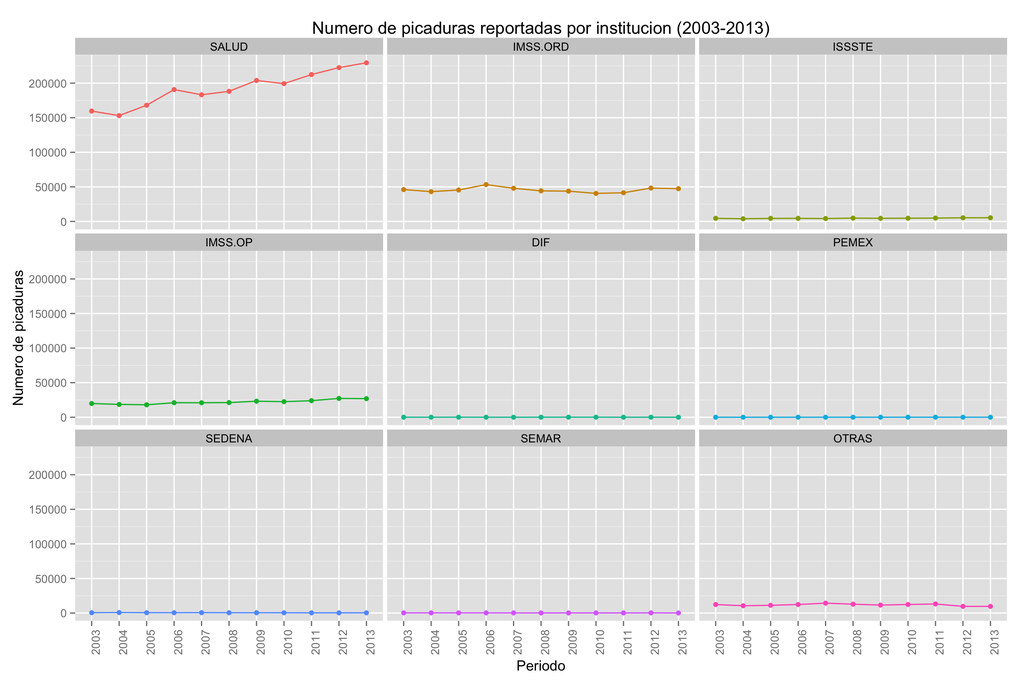

```r
library(ggplot2)


ggplot(INSTITUCION.PERIODO,aes(Periodo,No.Picaduras,group=Institucion))+geom_line(aes(colour=Institucion)) +facet_wrap(~Institucion,ncol=3)+ geom_point(aes(colour=Institucion))+labs(title="Numero de picaduras reportadas por institucion (2003-2013)",x="Periodo",y="Numero de picaduras")+theme(axis.text.x=element_text(angle=90))+theme(legend.position="none")
```

**Grafica 2: Barplot**

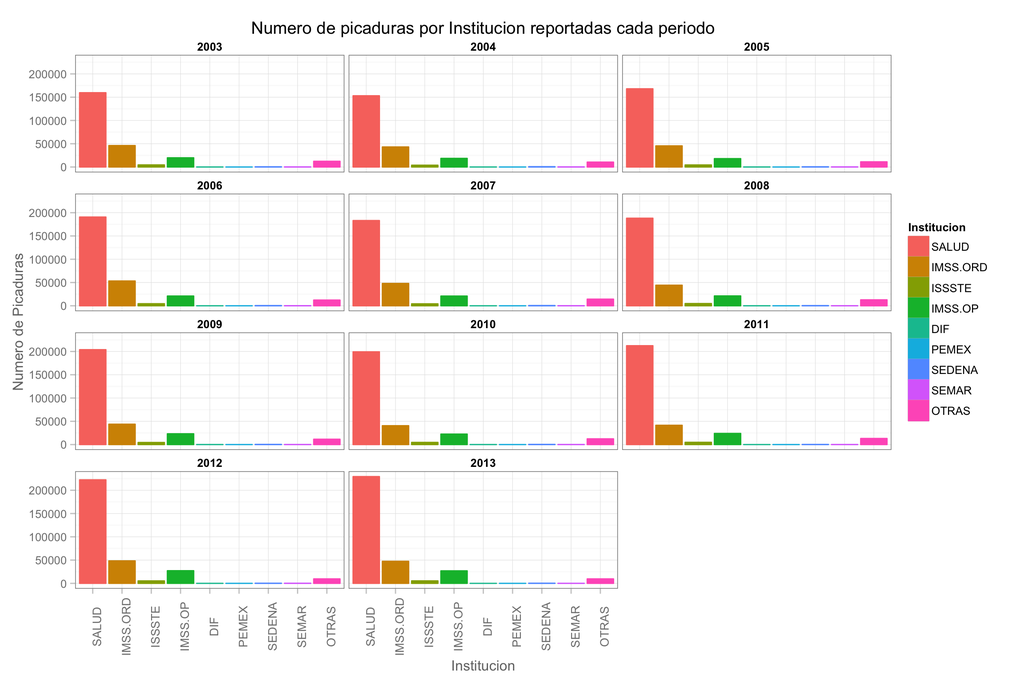

```r
ggplot(INSTITUCION.PERIODO,aes(x=Institucion,y=No.Picaduras,group=Periodo,fill=Institucion)) +geom_bar(stat="identity",aes(colour=Institucion))+facet_wrap(~Periodo,ncol=3)+theme_bw()+theme(axis.text.x=element_text(angle=90,size=10),strip.text = element_text(face = "bold"),strip.background = element_blank(),axis.text = element_text(colour=grey(.50)),axis.ticks=element_line(colour=grey(.80)),axis.title = element_text(colour=grey(.45)))+labs(title="Numero de picaduras por Institucion reportadas cada periodo",x="Institucion",y="Numero de Picaduras")
```

**Mensual**

Creamos una tabla auxiliar que nos indique el numero de picaduras de alacran por mes en cada periodo de observacion.

```r
mes.per <- NULL
periodo <- c(2003:2013)
for (i in 1:11){
  mes.per[[i]] <- as.list(colSums((subset(picadura.alacran.mes,Periodo==periodo[i] & Sexo=="General"))[,3:14],na.rm=TRUE))
}

names(mes.per) <- periodo

mes.periodo <- ldply(mes.per,data.frame)

names(mes.periodo) <- c("Periodo","ENE","FEB","MAR","ABR","MAY","JUN","JUL","AGO","SEP","OCT","NOV","DIC")

MES.PERIODO <- melt(mes.periodo,id=c("Periodo"),variable.name="Mes",value.name="No.Picaduras",na.rm=TRUE)

head(MES.PERIODO)
```

```
  Periodo Mes No.Picaduras
1    2003 ENE        14792
2    2004 ENE        10672
3    2005 ENE        11149
4    2006 ENE        16987
5    2007 ENE        17296
6    2008 ENE        13592
```

Grafica Uno: Evolucion anual de los casos de picadura de alacran (2003-2013)

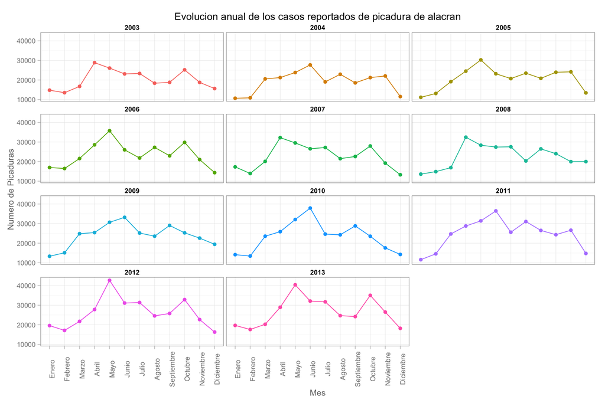

```r
ggplot(MES.PERIODO,aes(x=Mes,y=No.Picaduras,group=Periodo))+geom_line(aes(colour=Periodo))+geom_point(aes(colour=Periodo),size=2.5)+facet_wrap(~Periodo,ncol=3)+theme_bw()+theme(axis.text.x=element_text(angle=90,size=10),strip.text = element_text(face = "bold"),strip.background = element_blank(),axis.text = element_text(colour=grey(.50)),axis.ticks=element_line(colour=grey(.80)),axis.title = element_text(colour=grey(.45)))+labs(title="Evolucion anual de los casos reportados de picadura de alacran",x="Mes",y="Numero de Picaduras")+theme(legend.position="none")+scale_x_discrete("Mes",labels=c("ENE"="Enero","FEB"="Febrero","MAR"="Marzo","ABR"="Abril","MAY"="Mayo","JUN"="Junio","JUL"="Julio","AGO"="Agosto","SEP"="Septiembre","OCT"="Octubre","NOV"="Noviembre","DIC"="Diciembre"))
```

Grafica Dos: Tendencia Mensual vs Media Mensual (2003-2013)

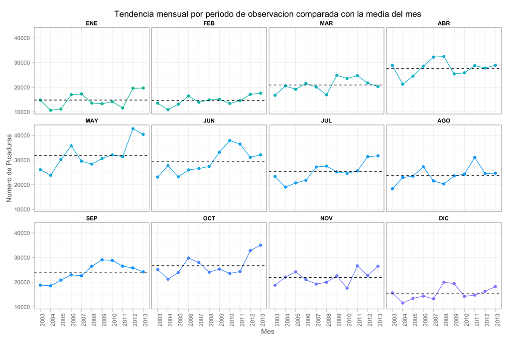

```r
#Creamos una tabla con las medias de cada mes

media.mes.1 <- as.data.frame(sapply(mes.periodo[,2:13],mean))
media.mes.1$Mes <- c("ENE","FEB","MAR","ABR","MAY","JUN","JUL","AGO","SEP","OCT","NOV","DIC")
names(media.mes.1) <- c("No.Picaduras","Mes")

#grafica
ggplot(MES.PERIODO,aes(x=Periodo,y=No.Picaduras,group=Mes))+geom_line(aes(colour=Mes))+geom_point(aes(colour=Mes),size=2.5)+facet_wrap(~Mes,ncol=4)+theme_bw()+theme(axis.text.x=element_text(angle=90,size=10),strip.text = element_text(face = "bold"),strip.background = element_blank(),axis.text = element_text(colour=grey(.50)),axis.ticks=element_line(colour=grey(.80)),axis.title = element_text(colour=grey(.45)))+labs(title="Tendencia mensual por periodo de observacion comparada con la media del mes",x="Mes",y="Numero de Picaduras")+theme(legend.position="none")+geom_hline(data=media.mes.1,aes(yintercept=No.Picaduras,group=Mes),linetype=2)+ scale_colour_hue(h=c(180, 270))
```

Mostramos los promedios mensuales de casos registrados.

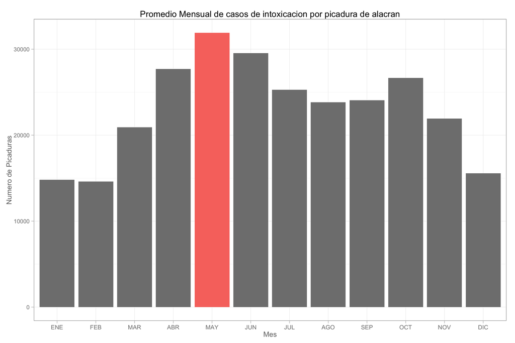

```r
color.prom <- c(NA,NA,NA,NA, "withcolor", NA, NA,NA,NA,NA,NA,NA)

ggplot(media.mes.1,aes(x=Mes,y=No.Picaduras,fill=color.prom))+geom_bar(stat="identity")+theme_bw()+theme(axis.text.x=element_text(size=10),strip.text = element_text(face = "bold"),strip.background = element_blank(),axis.text = element_text(colour=grey(.50)),axis.ticks=element_line(colour=grey(.80)),axis.title = element_text(colour=grey(.45)))+labs(title="Promedio Mensual de casos de intoxicacion por picadura de alacran",x="Mes",y="Numero de Picaduras")+theme(legend.position="none")+xlim("ENE","FEB","MAR","ABR","MAY","JUN","JUL","AGO","SEP","OCT","NOV","DIC")
```

Los meses en los que se presentan, en promedio, el mayor numero de casos es entre los meses de abril y junio, y alcanza su maximo en el mes de mayo.

Fijandonos en el mes de Mayo, veremos, en promedio, en que estado se presenta la mayor cantidad de casos registrados.

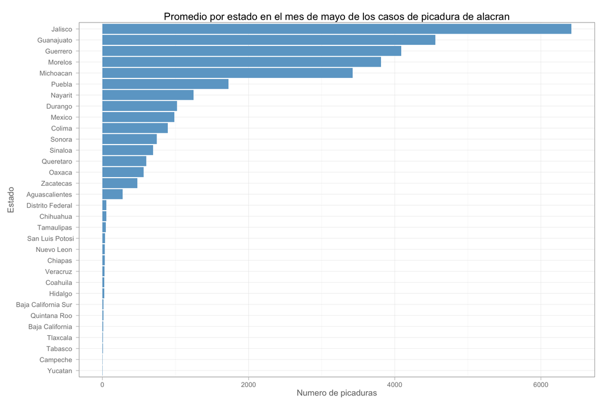

```r
library(reshape)

#Hacemos una tabla con el promedio de cada estado en el mes de mayo para el periodo de observacion (2003-2013)

Estado.prom <- cast(subset(PICADURA.ALACRAN.MES,Mes=="MAY" & Sexo=="General"), Mes~Estado, mean)

#Convertimos la tabla al formato largo
ESTADO.PROM.MAYO <- melt(Estado.prom,id=c("Mes"),variable.name="Estado")

#Creamos la grafica
ggplot(ESTADO.PROM.MAYO,aes(x=reorder(Estado,value),y=value,fill=Mes))+geom_bar(stat="identity")+theme_bw()+theme(strip.background = element_blank(),axis.text = element_text(colour=grey(.50)),axis.ticks=element_line(colour=grey(.80)),axis.title = element_text(colour=grey(.45)))+labs(title="Promedio por estado en el mes de mayo de los casos de picadura de alacran",x="Estado",y="Numero de picaduras")+theme(legend.position="none")+coord_flip()+scale_fill_manual(values = c("skyblue3"))
```

Comparacion de la evolucion anual de los casos de intoxicacion por picadura de alacran por generos

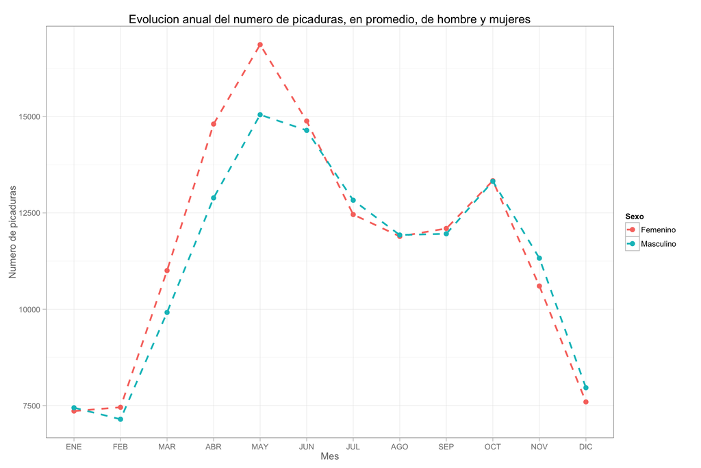

```r
#Primero hacemos una tabla con la suma mensual de cada a??o para cada sexo. Para esto hacemos dos: una para hombres y otra para mujeres; despues las juntamos con un merge
mes.per.fem <- NULL
periodo <- c(2003:2013)
for (i in 1:11){
  mes.per.fem[[i]] <- as.list(colSums((subset(picadura.alacran.mes,Periodo==periodo[i] & Sexo=="Femenino"))[,3:14],na.rm=TRUE))
}

names(mes.per.fem) <- periodo

mes.periodo.fem <- ldply(mes.per.fem,data.frame)

names(mes.periodo.fem) <- c("Periodo","ENE","FEB","MAR","ABR","MAY","JUN","JUL","AGO","SEP","OCT","NOV","DIC")
mes.periodo.fem$Sexo <- "Femenino"

mes.per.masc <- NULL
periodo <- c(2003:2013)
for (i in 1:11){
  mes.per.masc[[i]] <- as.list(colSums((subset(picadura.alacran.mes,Periodo==periodo[i] & Sexo=="Masculino"))[,3:14],na.rm=TRUE))
}

names(mes.per.masc) <- periodo

mes.periodo.masc <- ldply(mes.per.masc,data.frame)

names(mes.periodo.masc) <- c("Periodo","ENE","FEB","MAR","ABR","MAY","JUN","JUL","AGO","SEP","OCT","NOV","DIC")
mes.periodo.masc$Sexo <- "Masculino"

mes.periodo.sexo <- merge(mes.periodo.fem,mes.periodo.masc,all=TRUE)


#La convertimos a la estructura de formato largo
SEXO.MES <- melt(mes.periodo.sexo,id=c("Periodo","Sexo"))
names(SEXO.MES) <- c("Periodo","Sexo","Mes","No.Picaduras")

#Creamos una tabla con el promedio de cada sexo para cada mes de observacion y la convertimos a la estructura de formato largo

prom.sexo.mes <- cast(SEXO.MES,Mes~Sexo,mean)
PROM.SEXO.MENS <- melt(prom.sexo.mes,id=c("Mes"),variable.name="Sexo")

#Grafica

ggplot(PROM.SEXO.MENS,aes(x=Mes,y=value,group=Sexo))+geom_line(aes(colour=Sexo),linetype=2, size=1)+geom_point(aes(colour=Sexo),size=3)+theme_bw()+theme(strip.background = element_blank(),axis.text = element_text(colour=grey(.50)),axis.ticks=element_line(colour=grey(.80)),axis.title = element_text(colour=grey(.45)))+labs(title="Evolucion anual del numero de picaduras, en promedio, de hombre y mujeres",x="Mes",y="Numero de picaduras")
```

En general se ve que no hay mucha diferencia entre los casos registrados de hombres y de mujeres. La ligera diferencia entre los dos, especialmente entre los meses de febrero a junio, en donde se registraron m??s casos de mujeres, puede ser explicada por el hecho de que mas de la mitad del contacto con el alacran se da en los hogares y las mujeres, normalmente, est??n m??s tiempo en los hogares que los hombres.